# Lab 1: Gene expression microarrays and differential expression

Leslie Myint, Jean-Philippe Fortin

March 29, 2016

#### Package version: BiocStyle 1.8.0

# 1 Overview

We will be looking at data from a study of gene expression in chronic lymphocytic leukemia (CLL). The authors were interested in identifying genes that are differentially expressed in stable versus progressive cancers.

# 2 Reading your own data

Helpful information can be found in the [affy vignette](http://bioconductor.org/packages/release/bioc/vignettes/affy/inst/doc/affy.pdf) and the [affy reference manual](http://bioconductor.org/packages/release/bioc/manuals/affy/man/affy.pdf). Let’s say that I have .CEL files downloaded to a folder called “microarray” on my Desktop.

```r
# Navigate to the folder containing the .CEL files
setwd("~/Desktop/microarray/")
# Read in the data using...
abatch <- ReadAffy() # this reads in all .CEL files in this directory and stores in the abatch object
# ...or...
files <- list.files(".") # get filenames of every file in this directory
abatch <- read.affybatch(filenames = files)
```

# 3 Loading packages and data

If you don’t already have the packages installed:

```r
source("https://bioconductor.org/biocLite.R")
biocLite(c("CLL", "affy", "limma", "hgu95av2.db"))
install.packages("scales")
```

Load the packages:

```r
library(CLL)
library(affy)
```

What forms of data are available to us?

```r
data(package = "CLL")
```

We see that there are both raw and processed forms of data. **CLLbatch** is a raw data object. **disease** contains metadata information. **sCLLex** is an **ExpressionSet** object which means that it has gone through some processing. There are also some analysis results that we won’t be using. Let’s get the first objects into our R workspace:

```r
data(CLLbatch, sCLLex, disease, package = "CLL")
```

# 4 Exploratory data analysis

We can get some general information about the experiment by printing the **AffyBatch** object:

```r
CLLbatch # same as print(CLLbatch)
```

```
## AffyBatch object
## size of arrays=640x640 features (99224 kb)
## cdf=HG_U95Av2 (12625 affyids)
## number of samples=24
## number of genes=12625
## annotation=hgu95av2
## notes=
```

What sample classes do the arrays belong to?

```r
disease
```

```
##    SampleID  Disease
## 1     CLL10     <NA>
## 2     CLL11 progres.
## 3     CLL12   stable
## 4     CLL13 progres.
## 5     CLL14 progres.
## 6     CLL15 progres.
## 7     CLL16 progres.
## 8     CLL17   stable
## 9     CLL18   stable
## 10    CLL19 progres.
## 11     CLL1   stable
## 12    CLL20   stable
## 13    CLL21 progres.
## 14    CLL22   stable
## 15    CLL23 progres.
## 16    CLL24   stable
## 17     CLL2   stable
## 18     CLL3 progres.
## 19     CLL4 progres.
## 20     CLL5 progres.
## 21     CLL6 progres.
## 22     CLL7 progres.
## 23     CLL8 progres.
## 24     CLL9   stable
```

For ease of exploration and analysis later, let’s store the samples that belong to the two classifications of CLL (stable and progressive):

```r
samplesProg <- which(disease$Disease=="progres.")
samplesStable <- which(disease$Disease=="stable")
```

## 4.1 Microarray images

How do the microarray images look? Are there any obvious spatial artifacts?

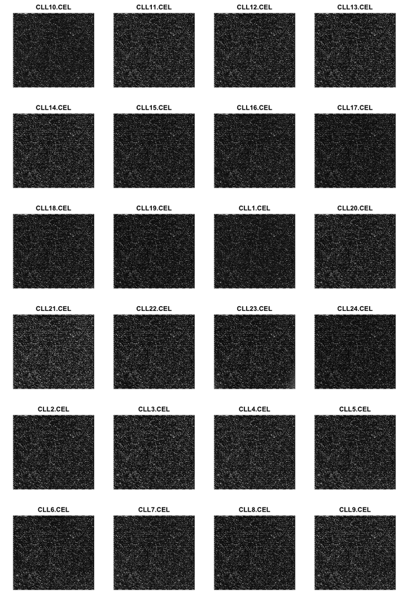

```r
# Plot all 24 of the array images (can be slow)
par(mfrow = c(6,4), mar = c(2,2,2,1))
image(CLLbatch)
```

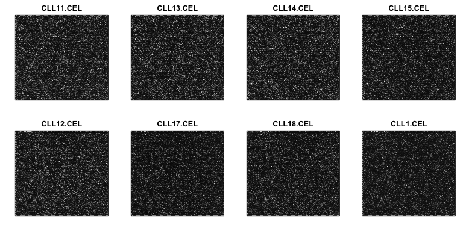

```r
# Plot the first 4 progressive and the first 4 stable samples
par(mfrow = c(2,4), mar = c(2,2,2,1))
image(CLLbatch[, c(samplesProg[1:4], samplesStable[1:4])])
```

## 4.2 Intensity distributions

We can also look at the distributions of log-intensities across the arrays:

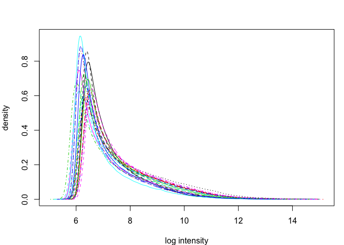

```r
par(mfrow = c(1,1), mar = c(4,4,3,1))
hist(CLLbatch)
```

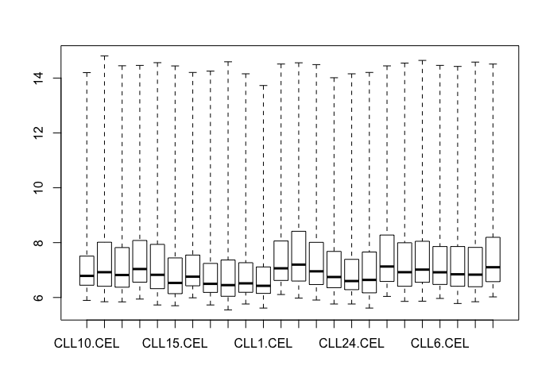

```r
boxplot(CLLbatch)
```

From the density estimates, we see a typical shape that resembles the mixture of a normal and an exponential distribution.

## 4.3 MA plots

MA plots of individual arrays versus individual arrays:

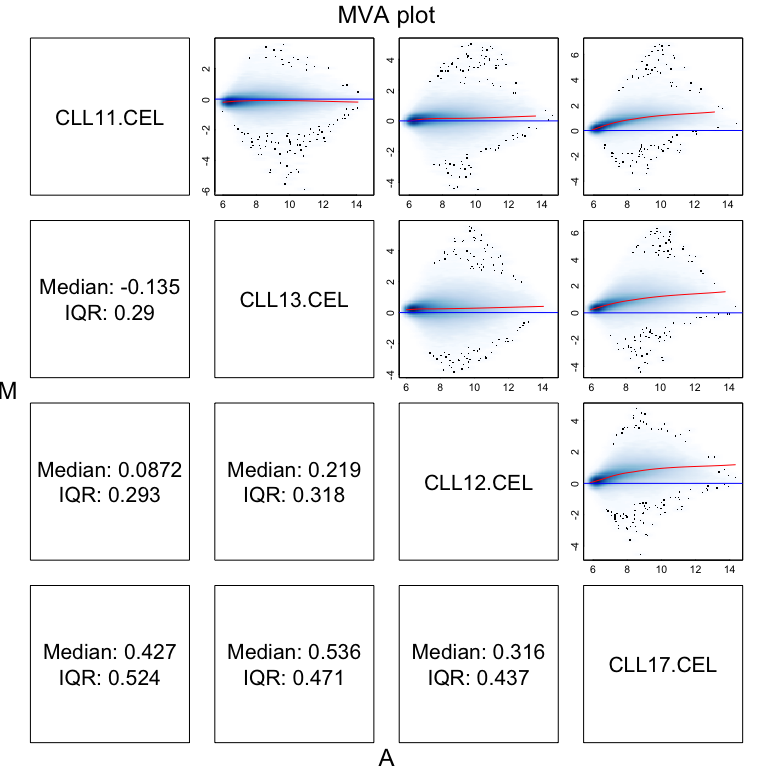

```r
par(mfrow = c(4,4), mar = c(4,4,3,1))
MAplot(CLLbatch[, c(samplesProg[1:2], samplesStable[1:2])], pairs = TRUE, plot.method = "smoothScatter")
```

We can make an MA plot of one group versus the other using the perfect match (PM) data in the **CLLbatch** object. First let’s get acquainted with the object containing the PM data.

```r
pmdata <- pm(CLLbatch)
head(pmdata)
```

```
##        CLL10.CEL CLL11.CEL CLL12.CEL CLL13.CEL CLL14.CEL CLL15.CEL
## 175218       107     169.0     188.3     221.8     153.5     113.0
## 356689       303     505.3     533.0     658.0     498.0     306.0
## 227696       535    1257.3    1265.0    1218.8    1060.5     833.3
## 237919        98     114.0     119.0     117.0     124.3      88.0
## 275173       152     381.0     285.0     404.3     384.5     185.0
## 203444        95     154.0     120.0     154.0     135.0     105.0
##        CLL16.CEL CLL17.CEL CLL18.CEL CLL19.CEL CLL1.CEL CLL20.CEL
## 175218     114.8     107.3      95.3     117.0     84.0     176.0
## 356689     340.8     269.0     294.3     280.3    228.5     507.0
## 227696     766.3     563.0     558.0     742.0    564.3    1046.0
## 237919      97.0      88.0      87.0      88.3     74.0     107.0
## 275173     180.0     190.5     204.0     193.0    111.3     318.5
## 203444     101.0     117.3      81.0      93.0     80.3     159.0
##        CLL21.CEL CLL22.CEL CLL23.CEL CLL24.CEL CLL2.CEL CLL3.CEL CLL4.CEL
## 175218     276.0     187.3     169.8     101.0    159.0    205.0    147.0
## 356689     790.0     569.5     437.5     349.3    421.0    621.0    473.0
## 227696    1571.8    1155.0     887.0     830.3   1122.3   1455.5   1044.0
## 237919     138.0     134.0     112.5      76.0    105.0    121.0    126.8
## 275173     660.5     395.0     312.0     177.0    293.0    326.0    322.3
## 203444     211.8     146.3     130.0      99.3    118.0    143.0    107.5
##        CLL5.CEL CLL6.CEL CLL7.CEL CLL8.CEL CLL9.CEL
## 175218    154.0    157.0    172.3    138.0    179.0
## 356689    561.8    534.0    564.0    409.0    581.3
## 227696   1054.0    898.3   1131.0   1094.5   1159.0
## 237919    117.0    110.0    116.3    117.0    117.8
## 275173    306.0    255.0    319.0    302.0    257.0
## 203444    133.0    129.0    148.3    134.8    140.0
```

```r
dim(pmdata)
```

```
## [1] 201800     24
```

```r
all.equal(paste0(disease$SampleID, ".CEL"), colnames(pmdata))
```

```
## [1] TRUE
```

We see that there are `201800` probes (rows) and that the ordering of the samples in the **disease** metadata object is the same as in the columns of the **pmdata** object. Now we can continue with the calculations needed to make the group vs. group MA plot. Instead of comparing one sample’s expression levels to another sample’s expression levels, we will compare the average expression levels in one group to those in the other group.

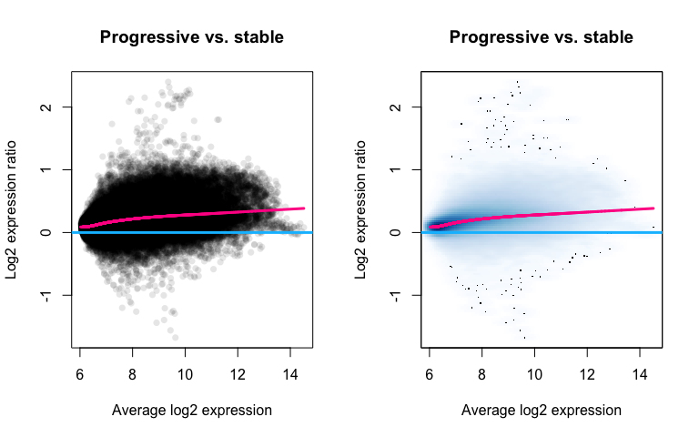

```r
logpmdata <- log2(pmdata + 1)
pmdataProg <- logpmdata[,samplesProg]
pmdataStable <- logpmdata[,samplesStable]
meanProg <- rowMeans(pmdataProg)
meanStable <- rowMeans(pmdataStable)
A <- (meanProg + meanStable)/2
M <- meanProg - meanStable
library(scales) # Need the scales package for alpha blending
par(mfrow = c(1,2))
plot(A, M, pch = 16, col = alpha("black", 0.1), xlab = "Average log2 expression", ylab = "Log2 expression ratio", main = "Progressive vs. stable")
abline(h = 0, lwd = 3, col = "deepskyblue")
lo <- lowess(A, M, f = 0.2)
lines(lo, lwd = 3, col = "deeppink")
# Can also use smoothScatter
smoothScatter(A, M, xlab = "Average log2 expression", ylab = "Log2 expression ratio", main = "Progressive vs. stable")
lines(lo, col = "deeppink", lwd = 3)
abline(h = 0, col = "deepskyblue", lwd = 3)
```

## 4.4 Probe(set) names

Each row of **pmdata** corresponds to a probe, and each probe belongs to a probeset (a set of probes targeting the same gene). We can get the probeset names with **geneNames** and the probeset that each probe belongs to with **probeNames**.

```r
pn <- probeNames(CLLbatch)
gn <- geneNames(CLLbatch)
identical(unique(pn), gn)
```

```
## [1] TRUE
```

```r
length(pn)==nrow(pmdata)
```

```
## [1] TRUE
```

```r
head(pn) # The first few probes all belong to the same probeset
```

```
## [1] "100_g_at" "100_g_at" "100_g_at" "100_g_at" "100_g_at" "100_g_at"
```

```r
head(gn)
```

```
## [1] "100_g_at"  "1000_at"   "1001_at"   "1002_f_at" "1003_s_at" "1004_at"
```

More information about the syntax for these probeset names can be found here: http://www.affymetrix.com/support/help/faqs/mouse_430/faq_8.jsp. We can obtain a subset of the perfect match (PM) or mismatch (MM) intensities corresponding to certain genes (probesets):

```r
pm(CLLbatch, gn[1])
```

```
##            CLL10.CEL CLL11.CEL CLL12.CEL CLL13.CEL CLL14.CEL CLL15.CEL
## 100_g_at1      107.0     169.0     188.3     221.8     153.5     113.0
## 100_g_at2      303.0     505.3     533.0     658.0     498.0     306.0
## 100_g_at3      535.0    1257.3    1265.0    1218.8    1060.5     833.3
## 100_g_at4       98.0     114.0     119.0     117.0     124.3      88.0
## 100_g_at5      152.0     381.0     285.0     404.3     384.5     185.0
## 100_g_at6       95.0     154.0     120.0     154.0     135.0     105.0
## 100_g_at7     1034.0    1082.3    1045.0    1159.8    1023.0     727.3
## 100_g_at8      421.3     789.0     719.0     808.0     724.8     432.8
## 100_g_at9      107.0     178.8     160.5     218.8     173.0     131.3
## 100_g_at10     130.5     230.0     190.0     248.3     246.0     155.0
## 100_g_at11     251.0     463.0     378.5     586.5     415.5     288.0
## 100_g_at12     229.0     732.0     664.0     672.0     628.0     417.8
## 100_g_at13     142.5     156.0     146.0     185.3     149.3     110.3
## 100_g_at14     230.3     488.0     331.0     590.3     422.3     277.3
## 100_g_at15     354.0     736.3     559.0     718.5     614.8     317.5
## 100_g_at16      91.0     115.3     100.0     103.5     110.0      82.5
##            CLL16.CEL CLL17.CEL CLL18.CEL CLL19.CEL CLL1.CEL CLL20.CEL
## 100_g_at1      114.8     107.3      95.3     117.0     84.0     176.0
## 100_g_at2      340.8     269.0     294.3     280.3    228.5     507.0
## 100_g_at3      766.3     563.0     558.0     742.0    564.3    1046.0
## 100_g_at4       97.0      88.0      87.0      88.3     74.0     107.0
## 100_g_at5      180.0     190.5     204.0     193.0    111.3     318.5
## 100_g_at6      101.0     117.3      81.0      93.0     80.3     159.0
## 100_g_at7      834.3     685.3     843.3     639.5    970.5    1169.0
## 100_g_at8      445.0     361.0     433.3     431.5    379.0     764.0
## 100_g_at9      139.0     135.0     117.0     118.0     83.0     184.5
## 100_g_at10     151.3     171.8     142.3     139.0     74.5     230.0
## 100_g_at11     273.0     293.0     288.0     255.3    185.0     485.0
## 100_g_at12     401.0     335.0     380.0     379.5    366.0     654.3
## 100_g_at13     132.0     113.0     119.0     119.5    100.0     177.0
## 100_g_at14     344.5     290.0     252.0     225.0    197.0     481.0
## 100_g_at15     444.0     350.0     357.0     315.3    241.3     531.0
## 100_g_at16      89.0      84.5      93.0      85.0     87.0     128.0
##            CLL21.CEL CLL22.CEL CLL23.CEL CLL24.CEL CLL2.CEL CLL3.CEL
## 100_g_at1      276.0     187.3     169.8     101.0    159.0    205.0
## 100_g_at2      790.0     569.5     437.5     349.3    421.0    621.0
## 100_g_at3     1571.8    1155.0     887.0     830.3   1122.3   1455.5
## 100_g_at4      138.0     134.0     112.5      76.0    105.0    121.0
## 100_g_at5      660.5     395.0     312.0     177.0    293.0    326.0
```

[output cut: 13 more lines]

```
## 100_g_at2     473.0    561.8    534.0    564.0    409.0    581.3
## 100_g_at3    1044.0   1054.0    898.3   1131.0   1094.5   1159.0
## 100_g_at4     126.8    117.0    110.0    116.3    117.0    117.8
## 100_g_at5     322.3    306.0    255.0    319.0    302.0    257.0
## 100_g_at6     107.5    133.0    129.0    148.3    134.8    140.0
## 100_g_at7    1197.3   1704.3   1405.0   1015.3    955.0   1657.0
## 100_g_at8     705.0    876.8    707.0    926.3    628.0    881.0
## 100_g_at9     179.0    179.5    171.8    203.8    147.0    155.0
## 100_g_at10    214.0    225.0    168.5    336.0    162.0    203.0
## 100_g_at11    400.8    380.0    393.3    455.0    275.0    441.0
## 100_g_at12    609.0    599.5    313.3    663.8    461.3    708.0
## 100_g_at13    181.3    161.0    160.5    183.3    139.0    164.0
## 100_g_at14    402.0    402.8    352.0    495.0    260.0    344.0
## 100_g_at15    593.0    712.3    495.0    611.0    371.0    647.3
## 100_g_at16    116.5    134.0    109.0    126.0    106.3    134.0
```

```r
mm(CLLbatch, gn[c(1,3)])
```

```
##            CLL10.CEL CLL11.CEL CLL12.CEL CLL13.CEL CLL14.CEL CLL15.CEL
## 100_g_at1       92.8     114.3     123.0     134.0     121.3      93.0
## 100_g_at2      207.0     257.3     271.0     353.0     357.0     226.3
## 100_g_at3     1088.0     804.5     905.8     781.3     861.3     774.8
## 100_g_at4      167.0     239.0     281.0     369.0     275.0     162.3
## 100_g_at5      123.0     193.5     182.0     209.0     202.0     138.8
## 100_g_at6       96.0     145.3     153.0     145.0     140.0     102.3
## 100_g_at7     2272.8    2737.0    2485.0    2801.8    2306.0    1657.0
## 100_g_at8      278.0     403.0     382.8     405.0     404.0     254.5
## 100_g_at9      112.0     114.0     114.0     125.8     104.0      80.5
## 100_g_at10      94.0     113.0     129.0     140.3     135.3      98.0
## 100_g_at11     326.3     669.0     457.0     835.0     578.0     336.0
## 100_g_at12     151.0     249.0     270.0     253.3     215.0     165.5
## 100_g_at13     130.0     131.0     108.0     148.0     109.3      95.0
## 100_g_at14     247.0     464.0     382.0     579.0     373.3     301.0
## 100_g_at15     120.8     123.0     131.8     154.3     118.0      95.8
## 100_g_at16      91.3     113.5      92.0     113.0     100.5      75.8
## 1001_at1       111.0     112.3      91.0     137.5     103.3      79.0
## 1001_at2       155.8     105.3      96.8     105.0      95.0      83.0
## 1001_at3        97.8     210.0     150.0     160.0     181.0     104.8
## 1001_at4        84.0      94.0      83.0      97.0      85.8      68.0
## 1001_at5        97.8     110.0     102.5     130.5     103.0      68.0
## 1001_at6        89.0     103.0      94.0     104.3      91.0      73.8
## 1001_at7       206.3     140.0     129.0     182.0     133.0     119.0
## 1001_at8       113.8     125.0     125.3     121.3     118.8     102.0
## 1001_at9       219.5     410.0     311.0     367.0     301.0     225.8
## 1001_at10       95.0     118.0     113.0     127.3     105.0      90.8
## 1001_at11      110.8     108.0     113.3     129.0     108.0      86.0
## 1001_at12       80.3      75.8      68.0      75.3      70.0      63.8
## 1001_at13       86.3      75.5      72.3      99.0      88.0      71.0
## 1001_at14       76.3      75.0      77.8      85.0      84.0      65.8
## 1001_at15       94.0      98.3      98.0     119.0      97.0      70.5
## 1001_at16       86.0      75.3      79.0      92.3      76.0      65.0
##            CLL16.CEL CLL17.CEL CLL18.CEL CLL19.CEL CLL1.CEL CLL20.CEL
## 100_g_at1       94.5      88.0      81.0      99.0     69.3     128.0
## 100_g_at2      208.5     142.0     157.0     156.0    138.0     266.0
## 100_g_at3      805.0     306.0     438.0     607.0   1917.3     817.0
## 100_g_at4      196.0     142.0     184.8     151.8    118.5     273.0
## 100_g_at5      154.0     150.0     122.8     135.3     96.3     171.0
## 100_g_at6      138.0      95.0      94.0     115.0     83.5     147.0
```

[output cut: 77 more lines]

```
## 1001_at2      106.3    129.0     94.0     96.3     89.0    113.8
## 1001_at3      165.5    171.3    129.0    190.0    129.5    168.8
## 1001_at4       85.0     84.5     74.0     90.0     97.0    109.8
## 1001_at5      109.5    104.8    102.3    128.0    104.0    106.3
## 1001_at6       91.0    113.0    103.0    100.0     87.0    100.5
## 1001_at7      130.3    178.8    166.0    124.0    122.0    171.0
## 1001_at8      110.0    173.0    133.3     97.0    102.0    188.0
## 1001_at9      260.0    377.3    233.8    308.0    407.0    345.0
## 1001_at10     106.0    158.0    115.0    111.5     95.0    139.8
## 1001_at11     108.0    124.5    114.3    120.0    112.8    124.3
## 1001_at12      78.0     76.0     82.0     77.0     78.0    101.0
## 1001_at13     100.0     97.3     77.0     78.0     75.8     99.0
## 1001_at14      79.0     93.0     83.0     81.5     74.0     94.0
## 1001_at15     113.0    130.0     96.5     98.3    106.0    114.0
## 1001_at16      81.0     87.0     83.5     83.5     77.0     85.0
```

# 5 Running processing algorithms

If you want to run RMA or MAS5 (the Affymetrix method), the quickest way to get a processed data object is to run:

```r
eset <- rma(CLLbatch)
eset <- mas5(CLLbatch)
```

To control exactly what methods are used at each stage of processing, we can use **expresso**:

```r
eset <- expresso(CLLbatch, normalize.method = "quantiles", bgcorrect.method = "rma", pmcorrect.method = "pmonly", summary.method = "liwong")
```

```
## background correction: rma
## normalization: quantiles
## PM/MM correction : pmonly
## expression values: liwong
## background correcting...done.
## normalizing...done.
## 12625 ids to be processed
## |                    |
## |####################|
```

More information on different methods for normalization (**normalize.method**), background correction (**bgcorrect.method**), probe-specific background correction (**pmcorrect.method**), and probe set summarization (**summary.method**) can be found in section 3.3 of the [affy overview vignette](https://bioconductor.org/packages/release/bioc/vignettes/affy/inst/doc/affy.pdf) and in the [affy built-in methods vignette](https://bioconductor.org/packages/release/bioc/vignettes/affy/inst/doc/builtinMethods.pdf).

In particular calling the **rma** function is equivalent to using **normalize.method = “quantiles”, bgcorrect.method = “rma”, pmcorrect.method = “pmonly”, summary.method = “medianpolish”** and calling the **mas5** function is equivalent to using **normalize.method = “constant”, bgcorrect.method = “mas”, pmcorrect.method = “mas”, summary.method = “mas”**.

## 5.1 Evaluating impact of processing

The **eset** object is an **ExpressionSet** object containing metadata information and processed expression values. We can extract the processed expression values with **exprs**:

```r
processed <- exprs(eset)
head(processed)
```

```
##           CLL10.CEL CLL11.CEL CLL12.CEL CLL13.CEL CLL14.CEL CLL15.CEL
## 100_g_at  311.56037 382.91936 410.25820 372.51179 347.78471 346.01757
## 1000_at   490.05017 911.83845 971.06215 785.42761 714.44293 611.41395
## 1001_at    74.95101  78.43814  61.91382  53.79857  61.69567  72.70726
## 1002_f_at  27.11407  21.23664  25.58967  26.78503  21.36181  25.08153
## 1003_s_at 114.31880 117.83886 133.42889 116.17532 115.22769 114.35010
## 1004_at   231.47269 452.13671 556.90103 541.22262 408.74050 266.83404
##           CLL16.CEL CLL17.CEL CLL18.CEL CLL19.CEL CLL1.CEL CLL20.CEL
## 100_g_at  365.49701 367.63463 307.45513 402.72329 382.3449 338.46636
## 1000_at   695.97069 888.43755 601.45974 863.12138 435.8124 806.37890
## 1001_at    73.06987  69.39833  55.27982  82.95521  69.8389  54.05756
## 1002_f_at  19.66355  20.90411  21.75599  27.52563  25.5633  17.81994
## 1003_s_at 171.58328 129.92539 111.34145 158.13176 133.1629 128.69289
## 1004_at   331.62789 218.41250 282.18421 316.95340 259.5969 737.32408
##           CLL21.CEL CLL22.CEL CLL23.CEL CLL24.CEL  CLL2.CEL  CLL3.CEL
## 100_g_at  378.33601 358.07070 408.38075 447.41874 410.24324 369.67511
## 1000_at   765.77002 922.50880 912.59151 786.16853 996.64435 786.66629
## 1001_at    56.11986  66.25919  70.87069  63.65542  74.58387  54.10477
## 1002_f_at  20.03552  17.02275  16.73265  20.39996  26.39909  20.11843
## 1003_s_at 102.10708 120.33229 111.32542 151.16722 149.38877 128.22389
## 1004_at   316.68811 493.56327 404.23540 254.28379 450.97455 878.30289
##            CLL4.CEL  CLL5.CEL   CLL6.CEL   CLL7.CEL  CLL8.CEL  CLL9.CEL
## 100_g_at  328.20016 357.70172  339.56330  414.86913 326.10695 330.23995
## 1000_at   736.12357 836.73941 1019.46825 1155.51218 812.39924 820.83378
## 1001_at    56.65604  64.40255   55.59633   64.38983  65.19065  54.87438
## 1002_f_at  17.55732  17.58934   20.95440   15.65833  20.33242  26.51814
## 1003_s_at 113.02834 147.98008  132.90602  111.82070 137.20186 128.15303
## 1004_at   349.52588 362.13025  478.18072  249.74775 645.08866 395.40372
```

```r
dim(processed)
```

```
## [1] 12625    24
```

```r
nrow(processed)==length(gn)
```

```
## [1] TRUE
```

Both boxplots and density plots show that processing causes the intensity distributions to be much more similar.

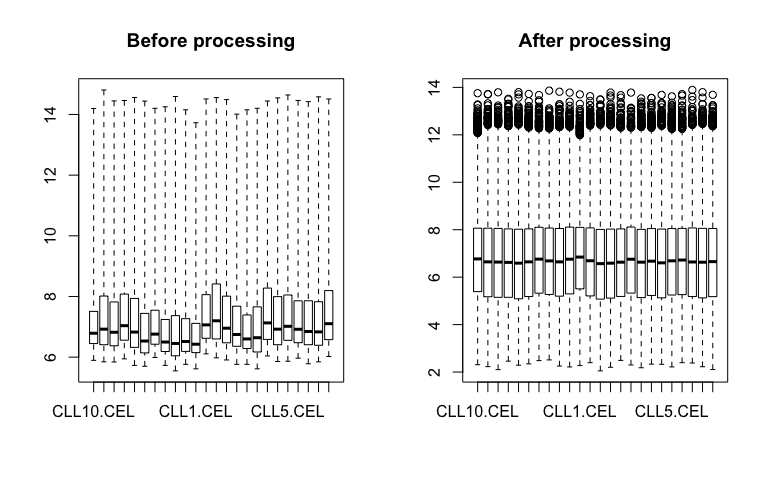

```r
par(mfrow = c(1,2))
boxplot(CLLbatch, main = "Before processing")
boxplot(log2(processed + 1), main = "After processing")
```

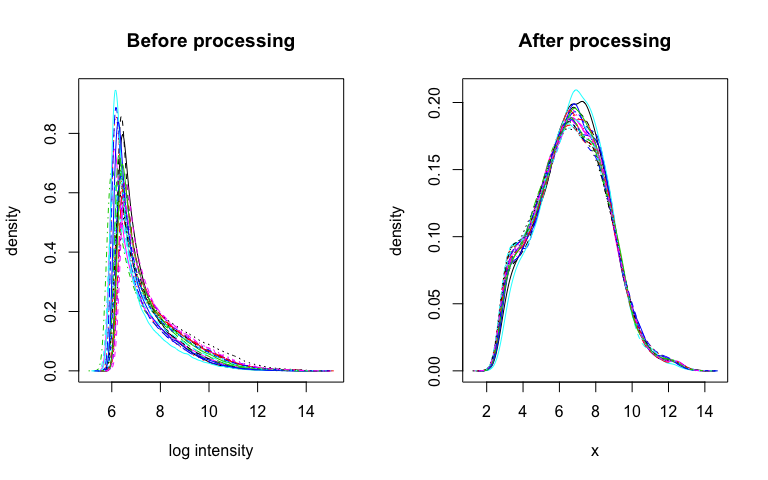

```r
par(mfrow = c(1,2))
hist(CLLbatch, main = "Before processing")
plotDensity(log2(processed + 1), main = "After processing")
```

We also see that the MA plot is more symmetric about $y = 0$.

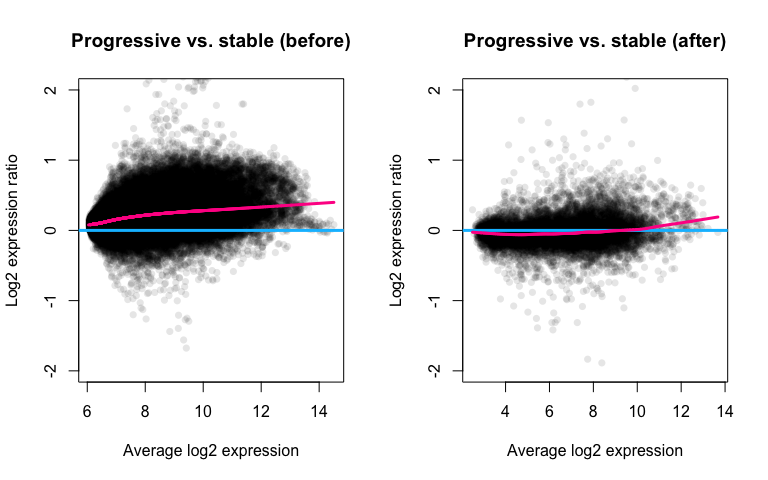

```r
A.pre <- rowMeans(logpmdata)
M.pre <- rowMeans(logpmdata[,samplesProg]) - rowMeans(logpmdata[,samplesStable])
par(mfrow = c(1,2))
plot(A.pre, M.pre, pch = 16, col = alpha("black", 0.1), xlab = "Average log2 expression", ylab = "Log2 expression ratio", main = "Progressive vs. stable (before)", ylim = c(-2,2))
abline(h = 0, lwd = 3, col = "deepskyblue")
lines(lowess(A.pre, M.pre, f = 0.2), lwd = 3, col = "deeppink")
A.post <- rowMeans(log2(processed + 1))
M.post <- rowMeans(log2(processed[,samplesProg] + 1)) - rowMeans(log2(processed[,samplesStable] + 1))
plot(A.post, M.post, pch = 16, col = alpha("black", 0.1), xlab = "Average log2 expression", ylab = "Log2 expression ratio", main = "Progressive vs. stable (after)", ylim = c(-2,2))
abline(h = 0, lwd = 3, col = "deepskyblue")
lines(lowess(A.post, M.post, f = 0.2), lwd = 3, col = "deeppink")
```

# 6 Differential expression analysis

**Goal:** Find genes that have statistically significant different abundances between two (or more) groups. In this case, the two conditions are progressive and stable chronic lymphocytic leukemia. We will use the package **limma** for analysis, and we will use the processed data from the original study which is contained in the **sCLLex** object.

```r
library(limma)
eset <- sCLLex
```

## 6.1 Linear model setup

For each gene, we want to fit the model $y_{i} = \beta_0 + \beta_1 x_i$ where $y_i$ is the gene’s expression value for sample $i$, $\beta_0$ is an intercept, $x_i$ is a dummy variable for group, and $\beta_1$ is the coefficient associated with the change in expression between the two groups. Our goal is to test $H_0: \beta_1 = 0$ for each gene.

## 6.2 Create design matrix

We extract the phenotype information and use this to construct our linear regression design matrix.

```r
pheno <- pData(eset)
groups <- as.factor(pheno$Disease)
designMat <- model.matrix(~groups)
colnames(designMat) <- c("Intercept","Disease")
designMat
```

```
##    Intercept Disease
## 1          1       0
## 2          1       1
## 3          1       0
## 4          1       0
## 5          1       0
## 6          1       0
## 7          1       1
## 8          1       1
## 9          1       0
## 10         1       1
## 11         1       0
## 12         1       1
## 13         1       0
## 14         1       1
## 15         1       1
## 16         1       0
## 17         1       0
## 18         1       0
## 19         1       0
## 20         1       0
## 21         1       0
## 22         1       1
## attr(,"assign")
## [1] 0 1
## attr(,"contrasts")
## attr(,"contrasts")$groups
## [1] "contr.treatment"
```

## 6.3 Linear model fitting

We can fit the linear models using the **lmFit** function in **limma**. All we need is an expression matrix containing the summarized intensities and the design matrix:

```r
fit <- lmFit(object = eset, design = designMat)
```

**fit** is an object containing the results of the fits. For instance, we can retrieve the coefficients of the linear model with

```r
head(fit$coefficients)
```

```
##           Intercept     Disease
## 1000_at    5.409914  0.12827699
## 1001_at    2.343562 -0.02602712
## 1002_f_at  3.389422  0.03478680
## 1003_s_at  1.114136  0.03308823
## 1004_at    7.482762 -0.12025210
## 1005_at    6.282123  0.60473144
```

## 6.4 Empirical Bayes variance estimation

Computing classical t-statistics for experiments with a small number of arrays is unstable. The empirical Bayes method implemented in **limma** borrows information about expression variability across genes to make the analysis more stable. Specifically, the function **eBayes** computes moderated t-statistics by estimating the standard errors using empirical Bayes moderation.

```r
fit2 <- eBayes(fit)
names(fit2)
```

```
##  [1] "coefficients"     "rank"             "assign"
##  [4] "qr"               "df.residual"      "sigma"
##  [7] "cov.coefficients" "stdev.unscaled"   "pivot"
## [10] "Amean"            "method"           "design"
## [13] "df.prior"         "s2.prior"         "var.prior"
## [16] "proportion"       "s2.post"          "t"
## [19] "df.total"         "p.value"          "lods"
## [22] "F"                "F.p.value"
```

## 6.5 Results

Let’s look at the distribution of p-values:

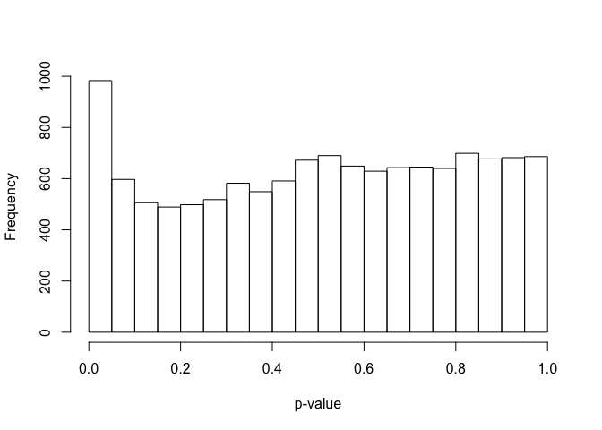

```r
par(mfrow = c(1,1))
hist(fit2$p.value[,2], xlab = "p-value", main = "")
```

A **volcano plot** is used to plot significance (e.g.instance p-value) versus fold-change (e.g. diff. expression coefficient):

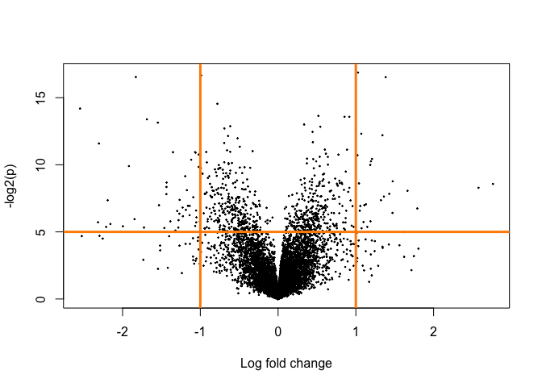

```r
p <- fit2$p.value[,2]
plot(fit2$coefficients[,2], -log2(p), pch = 20, cex = 0.3, xlab = "Log fold change")
abline(v = c(-1,1), lwd = 3, col = "darkorange")
abline(h = 5, lwd = 3, col = "darkorange")
```

**limma** has a command to produce a volcano plot on a fitted object produced by the **eBayes** command:

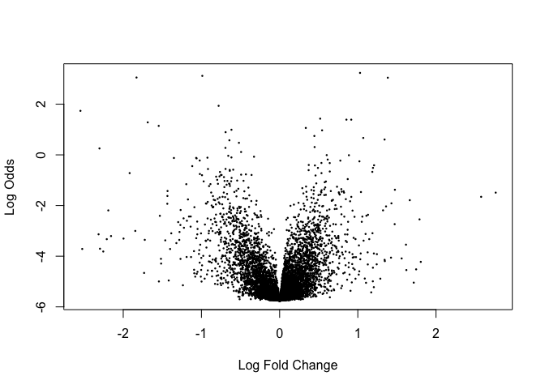

```r
volcanoplot(fit2, coef = 2)
```

## 6.6 Multiple testing adjustment

Because we are testing thousands of hypotheses, we need to correct our p-values for this multiplicity of tests. **p.adjust()** returns adjusted p-values for different methods:

```r
b.pvalues <- p.adjust(p, method = "bonferroni")
summary(b.pvalues)
```

```
##    Min. 1st Qu.  Median    Mean 3rd Qu.    Max.
##  0.1053  1.0000  1.0000  0.9997  1.0000  1.0000
```

```r
head(sort(b.pvalues))
```

```
##  39400_at  36131_at  33791_at   1303_at  36122_at  36939_at
## 0.1052998 0.1220524 0.1324065 0.1337647 0.5309707 0.6769971
```

```r
fdr.pvalues <- p.adjust(p, method = "fdr")
summary(fdr.pvalues)
```

```
##    Min. 1st Qu.  Median    Mean 3rd Qu.    Max.
## 0.03344 0.99990 0.99990 0.93680 0.99990 1.00000
```

```r
head(sort(fdr.pvalues))
```

```
##    1303_at   33791_at   36131_at   39400_at   36122_at   36939_at
## 0.03344118 0.03344118 0.03344118 0.03344118 0.10619415 0.11283285
```

We can also use the function **topTable** in the **limma** package to return the top differentially expressed genes. For instance, to return the top 100 genes that pass an uncorrected p-value threshold of $0.05$, we can use

```r
table <- topTable(fit2, coef = 2, adjust.method = "none", p.value = 0.05, number = 100)
head(table)
```

```
##               logFC  AveExpr         t      P.Value    adj.P.Val        B
## 39400_at  1.0284628 5.620700  5.835799 8.340576e-06 8.340576e-06 3.233915
## 36131_at -0.9888221 9.954273 -5.771526 9.667514e-06 9.667514e-06 3.116707
## 33791_at -1.8301554 6.950685 -5.736161 1.048765e-05 1.048765e-05 3.051940
## 1303_at   1.3835699 4.463438  5.731733 1.059523e-05 1.059523e-05 3.043816
## 36122_at -0.7801404 7.259612 -5.141064 4.205709e-05 4.205709e-05 1.934581
## 36939_at -2.5471980 6.915045 -5.038301 5.362353e-05 5.362353e-05 1.736846
```

# 7 Biological significance

We still don’t have the names of the genes associated with our probesets. We only have probset IDs. To map these probesets to genes, we need first to load the annotation package containing the relevant information for this Affymetrix array:

```r
library(hgu95av2.db)
columns(hgu95av2.db) # To see the info stored in the annotation
```

```
##  [1] "ACCNUM"       "ALIAS"        "ENSEMBL"      "ENSEMBLPROT"
##  [5] "ENSEMBLTRANS" "ENTREZID"     "ENZYME"       "EVIDENCE"
##  [9] "EVIDENCEALL"  "GENENAME"     "GO"           "GOALL"
## [13] "IPI"          "MAP"          "OMIM"         "ONTOLOGY"
## [17] "ONTOLOGYALL"  "PATH"         "PFAM"         "PMID"
## [21] "PROBEID"      "PROSITE"      "REFSEQ"       "SYMBOL"
## [25] "UCSCKG"       "UNIGENE"      "UNIPROT"
```

To find the gene symbol corresponding to the top 100 genes:

```r
probeNames <- rownames(table) # Names of the top 100 probes
info <- select(hgu95av2.db, probeNames, c("SYMBOL"), "PROBEID")
# Other names from columns(hgu95av2.db) can be added to the c("SYMBOL") above:
# info <- select(hgu95av2.db, probeNames, c("SYMBOL", "ENTREZID"), "PROBEID")
head(info)
```

```
##    PROBEID   SYMBOL
## 1 39400_at  TBC1D2B
## 2 36131_at    CLIC1
## 3 33791_at    DLEU1
## 4  1303_at   SH3BP2
## 5 36122_at    PSMA6
## 6 36122_at KIAA0391
```

```r
dim(info)
```

```
## [1] 110   2
```

Wait, we had `100` probes, and now we have `110` gene symbols. What’s wrong? It seems that some probesets map to more than one gene:

```r
table(table(info$PROBEID))
```

```
##
##  1  2  5
## 93  6  1
```

93 probesets map to 1 gene, 6 probesets map to 2 genes, and 1 probeset maps to 5 genes. Let’s use only the first gene mapped for each probeset:

```r
info <- info[match(probeNames, info$PROBEID),]
dim(info)
```

```
## [1] 100   2
```

We could have also decided to remove these probesets or something else depending on our downstream analysis plan. Add the gene symbol information to our table:

```r
table <- cbind(table, info$SYMBOL)
head(table)
```

```
##               logFC  AveExpr         t      P.Value    adj.P.Val        B
## 39400_at  1.0284628 5.620700  5.835799 8.340576e-06 8.340576e-06 3.233915
## 36131_at -0.9888221 9.954273 -5.771526 9.667514e-06 9.667514e-06 3.116707
## 33791_at -1.8301554 6.950685 -5.736161 1.048765e-05 1.048765e-05 3.051940
## 1303_at   1.3835699 4.463438  5.731733 1.059523e-05 1.059523e-05 3.043816
## 36122_at -0.7801404 7.259612 -5.141064 4.205709e-05 4.205709e-05 1.934581
## 36939_at -2.5471980 6.915045 -5.038301 5.362353e-05 5.362353e-05 1.736846
##          info$SYMBOL
## 39400_at     TBC1D2B
## 36131_at       CLIC1
## 33791_at       DLEU1
## 1303_at       SH3BP2
## 36122_at       PSMA6
## 36939_at       GPM6A
```